# HR ANALYTICS - EMPLOYEE ATTRITION

## 4.11. Overtime - Attrition

```python
tab = pd.crosstab(df.Attrition, columns= df.OverTime)
tab
```

| OverTime Attrition | No | Yes |
| --- | --- | --- |
| No | 944 | 289 |
| Yes | 110 | 127 |

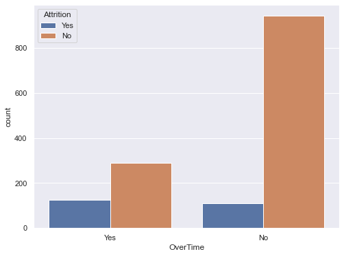

```python
sns.set(rc={'figure.figsize':(8,6)})
sns.countplot(x='OverTime', data=df, hue='Attrition')
```

```python
print("Attrition rate for Overtime: ", round((127/416)*100,2))
print("Attrition rate for no overtime: ", round((110/1054)*100,2))
```

```
Attrition rate for Overtime:  30.53
Attrition rate for no overtime:  10.44
```

**Hypothesis:**

- People doing overtime are leaving the comapny frequently.

**Inference:**

- People doing overtime has 30.53% probability of leaving the comapany as compared to the people who are not doing overtime and still are prone to leave the company with 10.44% probability

## 4.12. Total working years - Attrition

```python
df["TotalWorkingYears"].describe()
```

```
count    1470.000000
mean       11.279592
std         7.780782
min         0.000000
25%         6.000000
50%        10.000000
75%        15.000000
max        40.000000
Name: TotalWorkingYears, dtype: float64
```

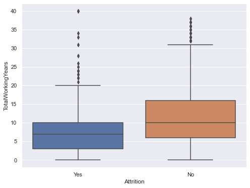

```python
sns.boxplot(x = "Attrition", y = "TotalWorkingYears", data=df)
```

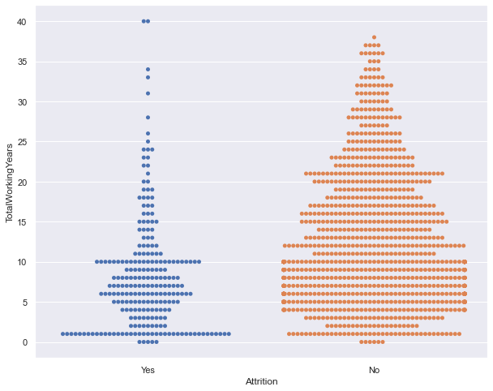

```python
sns.set(rc={'figure.figsize':(10,8)})
sns.swarmplot(x = "Attrition", y = "TotalWorkingYears", data=df)
```

```python
a=np.quantile(df[df['Attrition']=='Yes']['TotalWorkingYears'],0.25)
b=np.quantile(df[df['Attrition']=='Yes']['TotalWorkingYears'],0.75)
iqr = b-a
print("IQR:",iqr)
ub = b + 1.5*iqr
lb = a - 1.5*iqr
print("Upper bound:",ub)
print("Lower bound:",lb)
```

```
IQR: 7.0
Upper bound: 20.5
Lower bound: -7.5
```

**Hypothesis:**

- People who are new to the company and has gained experience of 1 year or so, they are more tending to leave the company.

**Inferences:**

- We can notice in the plots that People with experience in range 0-2 years are more prone to quit, but we can see people with either 5 or 10 years of experience quitting as well.

## 4.13. Work Life Balance - Attrition

```python
tab = pd.crosstab(df.Attrition, columns=df.WorkLifeBalance)
tab
```

| WorkLifeBalance Attrition | 1 | 2 | 3 | 4 |
| --- | --- | --- | --- | --- |
| No | 55 | 286 | 766 | 126 |
| Yes | 25 | 58 | 127 | 27 |

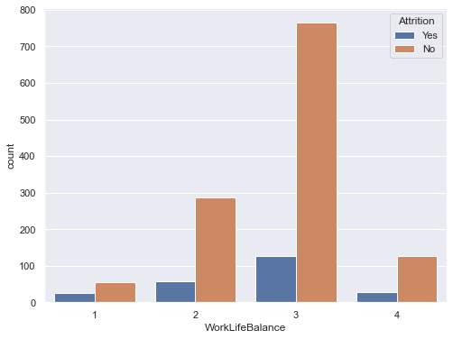

```python
sns.set(rc={'figure.figsize':(8,6)})
sns.countplot(x='WorkLifeBalance', data=df, hue='Attrition')
```

```python
print("Attrition rate for voting 1: ", round((25/80)*100,2))
print("Attrition rate for voting 2: ", round((58/344)*100,2))
print("Attrition rate for voting 3: ", round((127/839)*100,2))
print("Attrition rate for voting 4: ", round((27/153)*100,2))
```

```
Attrition rate for voting 1:  31.25
Attrition rate for voting 2:  16.86
Attrition rate for voting 3:  15.14
Attrition rate for voting 4:  17.65
```

**Hypothesis**

- People who have rated 1 for work life balance has high attrition rate.

**Observation**

- People who have rated 1 has the highest attrition rate. ##### Interestingly the second highest rate of attrition i.e. 17.65% can be observed from the people who have voted 4.

## 4.14. Years at company - Attrition

```python
df['YearsAtCompany'].describe()
```

```
count    1470.000000
mean        7.008163
std         6.126525
min         0.000000
25%         3.000000
50%         5.000000
75%         9.000000
max        40.000000
Name: YearsAtCompany, dtype: float64
```

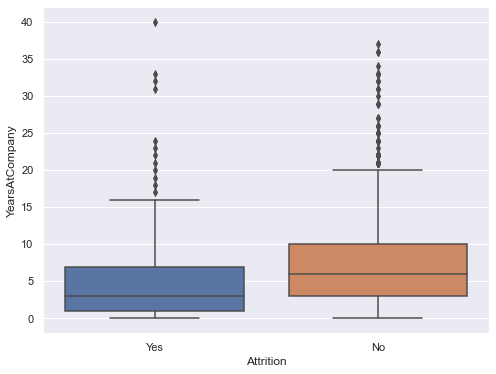

```python
sns.boxplot(x = 'Attrition', y = 'YearsAtCompany', data = df)
```

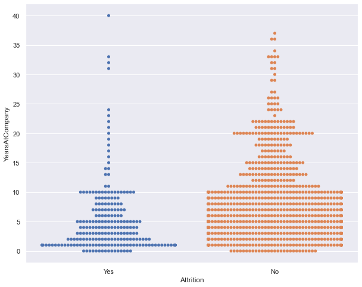

```python
sns.set(rc={'figure.figsize':(10,8)})
sns.swarmplot(x = 'Attrition', y = 'YearsAtCompany', data = df)
```

```python
a=np.quantile(df[df['Attrition']=='Yes']['YearsAtCompany'],0.25)
b=np.quantile(df[df['Attrition']=='Yes']['YearsAtCompany'],0.75)
iqr = b-a
print("IQR:",iqr)
ub = b + 1.5*iqr
lb = a - 1.5*iqr
print("Upper bound:",ub)
print("Lower bound:",lb)
```

```
IQR: 6.0
Upper bound: 16.0
Lower bound: -8.0
```

**Hypothesis:**

- People who are new to the company has high probability of leaving it.

**Observation**

- The maximum frequency of people leaving the firm can be seen in the range of 0-2 years, although we have people leaving the firm at 40 years as well

## 4.15. Years in Current role - Attrition

```python
df['YearsInCurrentRole'].describe()
```

```
count    1470.000000
mean        4.229252
std         3.623137
min         0.000000
25%         2.000000
50%         3.000000
75%         7.000000
max        18.000000
Name: YearsInCurrentRole, dtype: float64
```

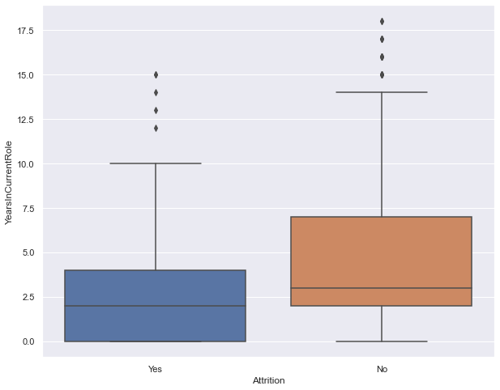

```python
sns.boxplot(x = 'Attrition', y = 'YearsInCurrentRole', data = df)
```

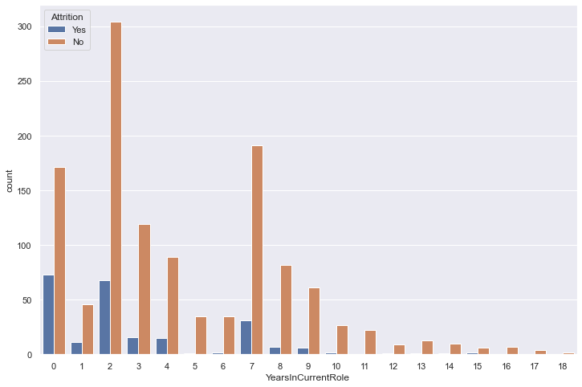

```python
sns.set(rc={'figure.figsize':(12,8)})
sns.countplot(x='YearsInCurrentRole',hue="Attrition", data=df)
```

```python
a=np.quantile(df[df['Attrition']=='Yes']['YearsInCurrentRole'],0.25)
b=np.quantile(df[df['Attrition']=='Yes']['YearsInCurrentRole'],0.75)
iqr = b-a
print("IQR:",iqr)
ub = b + 1.5*iqr
lb = a - 1.5*iqr
print("Upper bound:",ub)
print("Lower bound:",lb)
```

```
IQR: 4.0
Upper bound: 10.0
Lower bound: -6.0
```

**Hypothesis:**

- People who has spent more years in current role will leave the company.

**'Observation:**

- People with even 0 years in current role (maybe they have shifted from another role to a new role) accounts to 74 in total count and has left the company.
- There are only 4-5 people who has left the company for spending around 12 -15 years in the current role, so this nullify our hypothesis.

## 4.16. Years since last promotion - Attrition

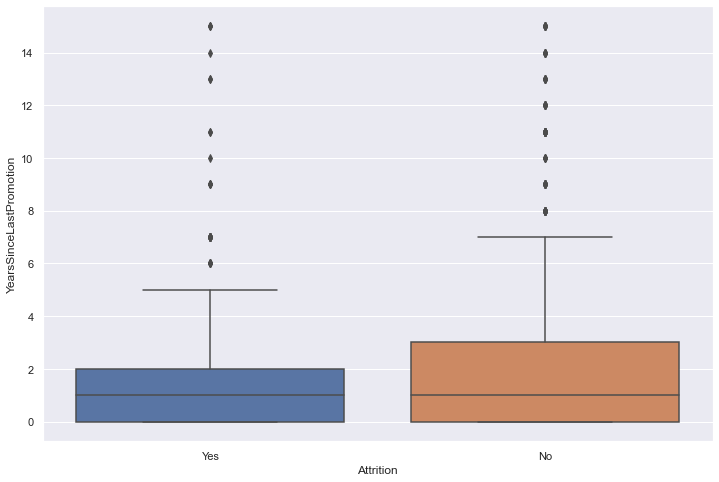

```python
sns.boxplot(x = 'Attrition', y = 'YearsSinceLastPromotion', data = df)
```

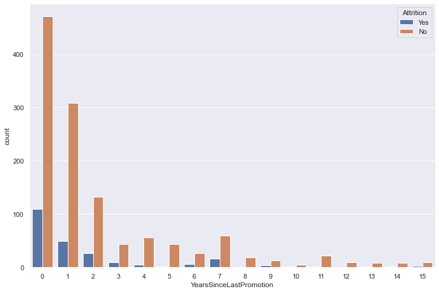

```python
sns.set(rc={'figure.figsize':(12,8)})
sns.countplot(x='YearsSinceLastPromotion',hue="Attrition", data=df)
```

```python
a=np.quantile(df[df['Attrition']=='Yes']['YearsSinceLastPromotion'],0.25)
b=np.quantile(df[df['Attrition']=='Yes']['YearsSinceLastPromotion'],0.75)
iqr = b-a
print("IQR:",iqr)
ub = b + 1.5*iqr
lb = a - 1.5*iqr
print("Upper bound:",ub)
print("Lower bound:",lb)
```

```
IQR: 2.0
Upper bound: 5.0
Lower bound: -3.0
```

**Hypothesis:**

- People who have longer time interval since last promotion should be leaving the company.

**Observation**

- People with 0-2 years since last promotion has more frequeny to leave the company, in comparison to people who had long time interval since last promotion which nullify our hypothesis.

## 4.17. Years with current manager - Attrition

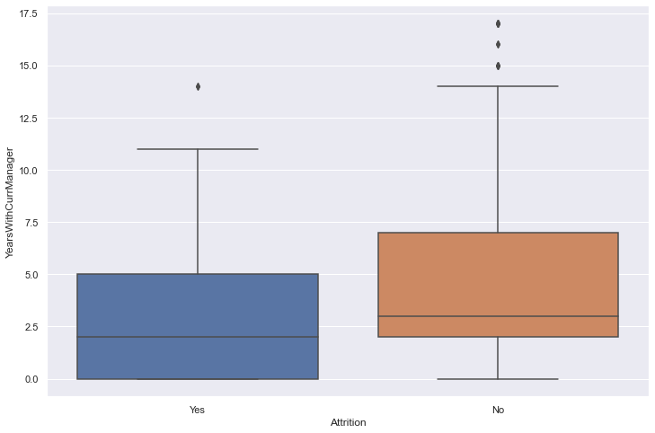

```python
sns.boxplot(x = 'Attrition', y = 'YearsWithCurrManager', data = df)
```

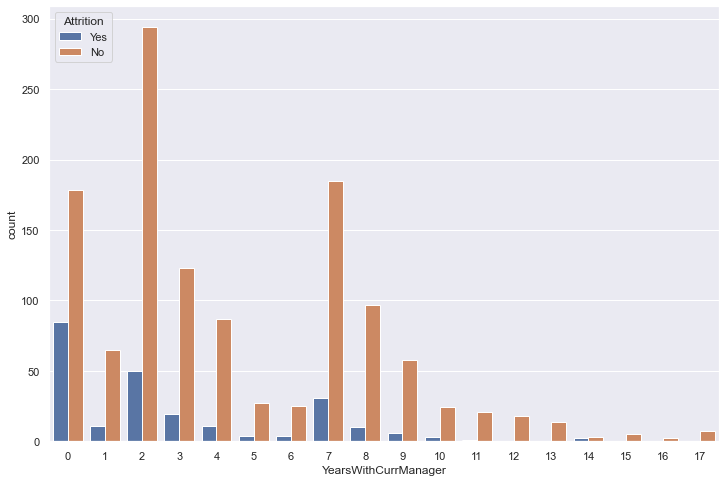

```python
sns.set(rc={'figure.figsize':(12,8)})
sns.countplot(x='YearsWithCurrManager',hue="Attrition", data=df)
```

```python
a=np.quantile(df[df['Attrition']=='Yes']['YearsWithCurrManager'],0.25)
b=np.quantile(df[df['Attrition']=='Yes']['YearsWithCurrManager'],0.75)
iqr = b-a
print("IQR:",iqr)
ub = b + 1.5*iqr
lb = a - 1.5*iqr
print("Upper bound:",ub)
print("Lower bound:",lb)
```

```
IQR: 5.0
Upper bound: 12.5
Lower bound: -7.5
```

**Hypothesis:**

- People with longer time period will be leaving the company frequently than other people.

**Observation:**

- In this we can see, mostly people within 7 years of experience with current manager are more prone to leave the company as compared to the people who have already been with current manager for more than 7 years.

## 4.18. Distance from Home - Attrition

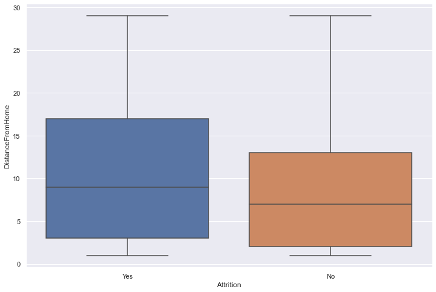

```python
sns.boxplot(x = 'Attrition', y = 'DistanceFromHome', data = df)
```

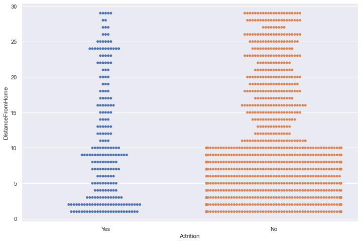

```python
sns.swarmplot(x = 'Attrition', y = 'DistanceFromHome', data = df)
```

```python
a=np.quantile(df[df['Attrition']=='Yes']['DistanceFromHome'],0.25)
b=np.quantile(df[df['Attrition']=='Yes']['DistanceFromHome'],0.75)
iqr = b-a
print("IQR:",iqr)
ub = b + 1.5*iqr
lb = a - 1.5*iqr
print("Upper bound:",ub)
print("Lower bound:",lb)
```

```
IQR: 14.0
Upper bound: 38.0
Lower bound: -18.0
```

**Hypothesis**

- People living far away will be leaving the company more often due to lead time increase in reaching to work.

**Observation:**

- People who are living within the radius of 0-2 kms are leaving the company more frequently than the people living far off.

# 5. Multivariate Analysis

## 5.1. Plotting correlation matrix

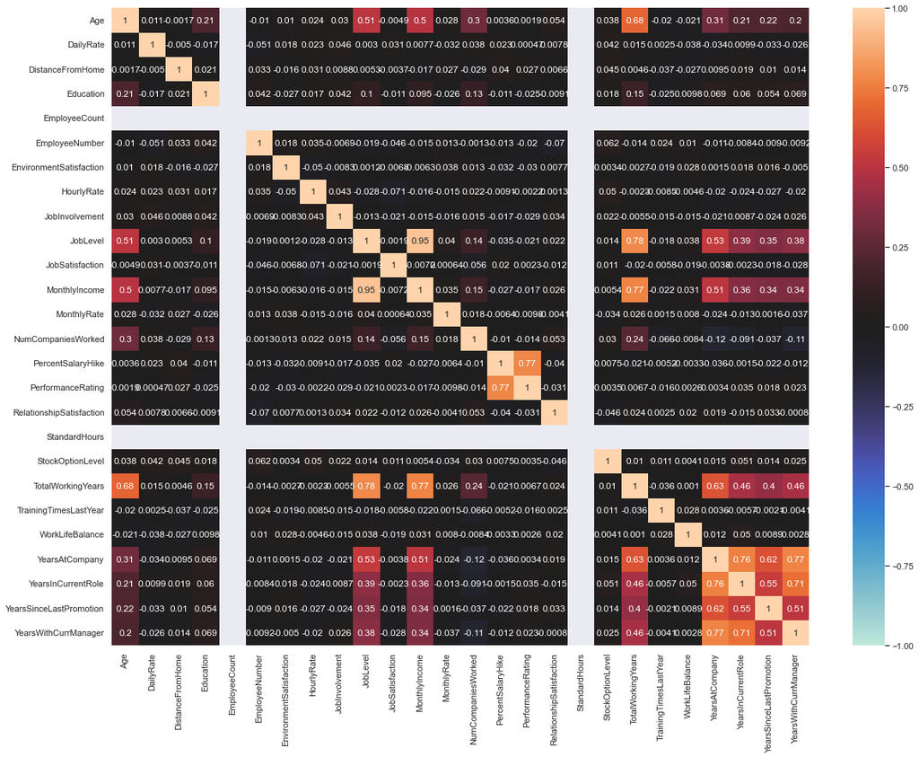

```python
sns.set(rc={'figure.figsize':(20,15)})
sns.heatmap(df.corr(), annot = True, vmin=-1, vmax=1, center= 0)
```

## 5.2. Comparing Attrition, Years since Last Promotion and Years in Current Role.

### Hypothesis: Employees having spent more than 5 years in Current Role yet not getting Promotion for >=5 years, are leaving the Company

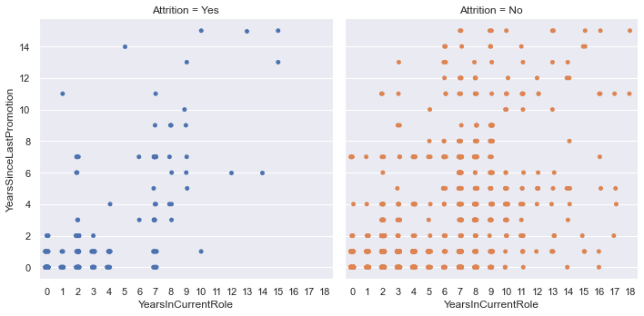

```python
sns.factorplot(x="YearsInCurrentRole",
                   y="YearsSinceLastPromotion",
                   data=df,
                   hue='Attrition',  # Color by stage
                   col='Attrition',  # Separate by stage
                   kind='strip');
```

## 5.3 Comparing Attrition, Job Satisfaction and Monthly income

### Hypothesis: Employees with Lower Monthly Income and with Less Job satisfaction are leaving the Company.

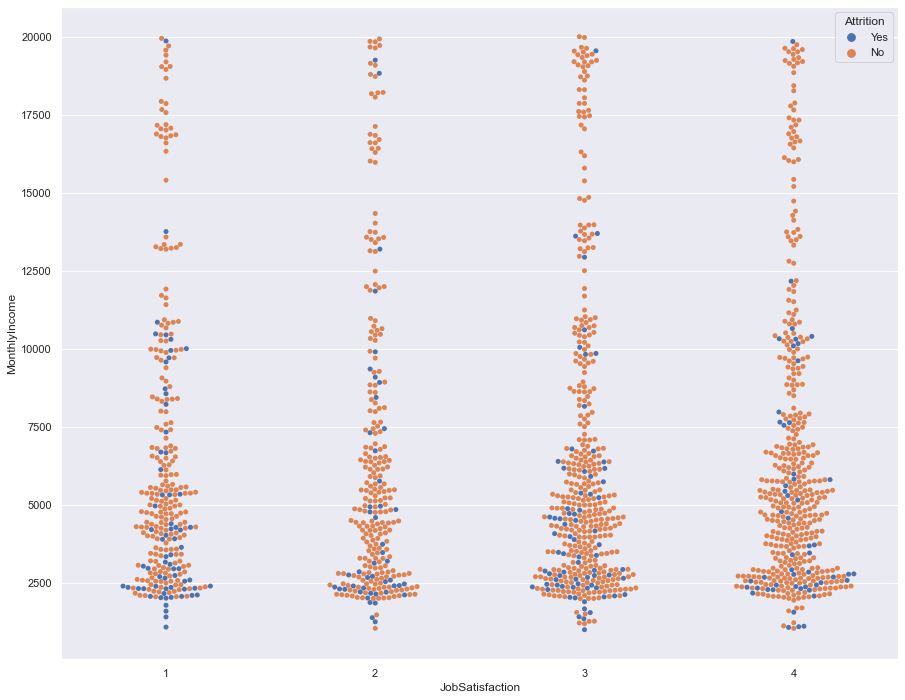

```python
sns.set(rc={'figure.figsize':(15,12)})
sns.swarmplot(x="JobSatisfaction", y="MonthlyIncome", hue="Attrition", data=df);
```

**Fact:**

- Employee with Lower monthly income & lowest Job Satisfaction are more prone to leave the Company but Employees with lower Monthly Income but Satisfaction level as good as 3, are also leaving the company at higher rates. In a few exceptional cases Employees with highest salary and with lowest to highest Job Satisfaction are also leaving the Company.

## 5.4. Comparing Attrition, Age and Monthly Income.

### Hypothesis: Employees at younger age with Lower Monthly Income are more vulnerable, leading to Employee Attrition.

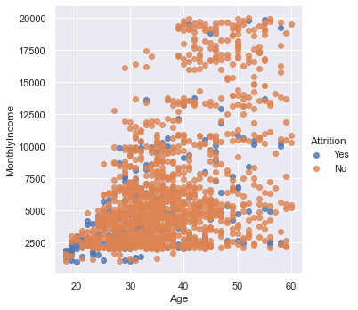

```python
sns.lmplot(x = 'Age', y ='MonthlyIncome', fit_reg=False, data = df, hue= 'Attrition');
```

**Fact:**

- The highest number of Attrition is seen among Employees of age-group 20-35 under Monthly Income Rs.10000. Our hypothesis holds true.

## 5.5. Comparing Attrition, Years in Current Role and Total Working Years.

### Hypothesis: Employees with more than 15 years of Work Experience and more than 5 years in the Current Role are leaving the company.

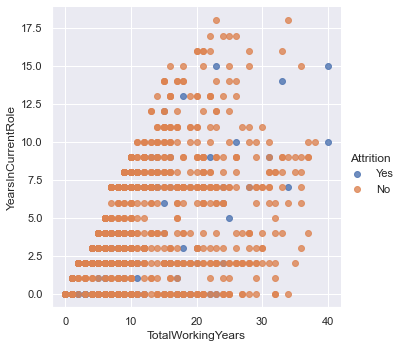

```python
sns.lmplot(x = 'TotalWorkingYears', y ='YearsInCurrentRole', fit_reg=False, data = df, hue= 'Attrition');
```

**Fact:**

- Employees under 14years of Work Experience and having spent upto 0-7 years in Current Role are mostly seen to be leaving the Company than Employees with around 15+ years of Total Working Years, so the hypothesis fails.

## 5.6. Comparing Attrition, Years with Current Manager and Years in Current Role.

### Hypothesis: Employees with 10+ years in Current role and 10+ years under same Manager are attriting.

[output not shown]

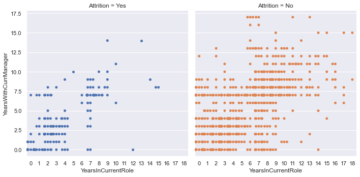

```python
sns.factorplot(x="YearsInCurrentRole",
                   y="YearsWithCurrManager",
                   data=df,
                   hue='Attrition',  # Color by stage
                   col='Attrition',  # Separate by stage
                   kind='swarm');
```

**Fact:**

- Our Hypothesis fails to hold true as we can clearly see that most number of Employees leaving the job belong to <=10 years with the current manager and around <=5 years in Current role!

## 5.7. Comparing Job Level, Monthly Income and Attrition.

### Employess at Higher Job Level and Lower Monthly Income are leaving the Company.

[output not shown]

[figure not shown]

```python
sns.set(rc={'figure.figsize':(12,8)})
sns.factorplot(x='JobLevel',
                   y='MonthlyIncome',
                   data=df,
                   hue='Attrition',  # Color by stage
                   col='Attrition',  # Separate by stage
                   kind='swarm');
```

**Fact:**

- Employees at Job Level 1, with monthly income less than 5000 are more prone to leave the Company against our Hypothesis of Employess at Higher Job Level and Lower Monthly Income are leaving the Company.

## 5.8. Comparing Attrition, Job Level and Years in Current Role.

### Employees having spent more than 5 years in the Current Role at lower level, are leaving the Company.

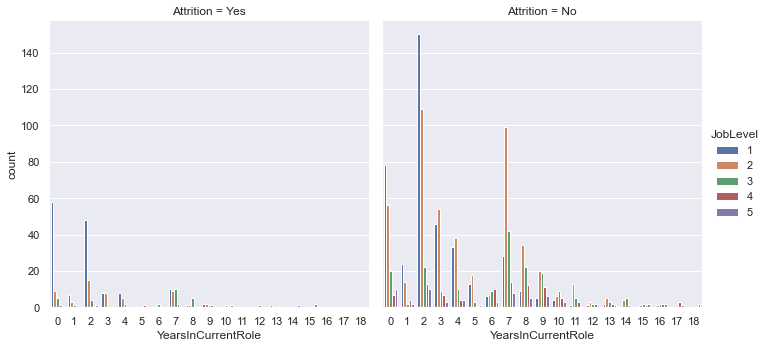

```python
sns.set(rc={'figure.figsize':(12,8)})
sns.catplot(x='YearsInCurrentRole', data=df, hue="JobLevel", col="Attrition", kind="count");
```

**Fact:**

- It is clearly evident from the graphs that Employees at lower level with less than 4 years in Current role are leaving the company. So our hypothesis fails to hold true.

## 5.9. Comparing Attrition, Job Satisfaction and Job Level.

### Hypothesis : Employees at Lower Job Level with Low Job Satisfaction are leaving the Company.

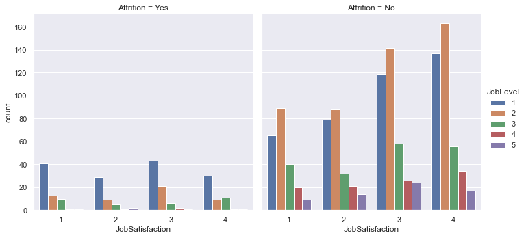

```python
sns.set(rc={'figure.figsize':(12,8)})
sns.catplot(x='JobSatisfaction', data=df, hue="JobLevel", col="Attrition", kind="count");
```

**Fact:**

- We can clearly see that attrition is more in case of Employees at Lower Job levels at any level of Job Satisfaction. Our Hypothesis is partially correct.

## 5.10. Comparing Attrition, Gender and Marital Status.

### Hypothesis: 1. Married-Female Employees are more prone to leave the Company.

### Hypothesis: 2. Unmarried-Male Employees are more prone to leave the Company.

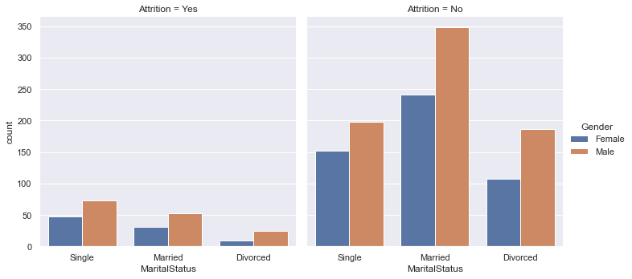

```python
 sns.catplot(x='MaritalStatus', data=df, hue="Gender", col="Attrition", kind="count");
```

**Fact**

- The rate of attrition is mostly seen in Employees with Marital Status as Single, so our Hypothesis 1 fails. However among singles, male employees are leaving more so our 2nd Hypothesis that Unmarried-Male employees are more prone to leave the Company holds true!

## 5.11. Comparing Attrition, Years in company and Years in current role.

### Employees with more than 5 years in the Company in their Current Role are leaving the Company

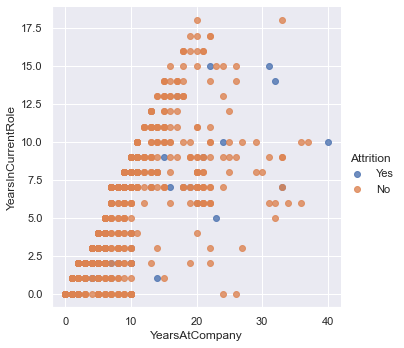

```python
sns.lmplot(x = 'YearsAtCompany', y ='YearsInCurrentRole', fit_reg=False, data = df, hue= 'Attrition');
```

**Fact:**

- Most of the attrition is seen among Employees under 6 years At Company while being in their Current Role for about 0-4 years.

## 5.12. Comparing Attrition, Overtime and Years Since Last Promotion.

### Hypothesis: Employees doing Overtime but not getting Promoted for past 5 years are leaving the Company.

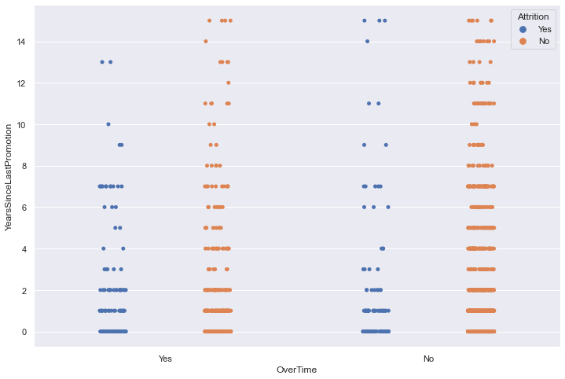

```python
sns.set(rc={'figure.figsize':(12,8)})
sns.stripplot(x = 'OverTime', y = 'YearsSinceLastPromotion', hue = 'Attrition', data=df, jitter = True, dodge = True)
```

```
<module 'matplotlib' from 'C:\\Users\\UMAIR\\anaconda3\\lib\\site-packages\\matplotlib\\__init__.py'>
```

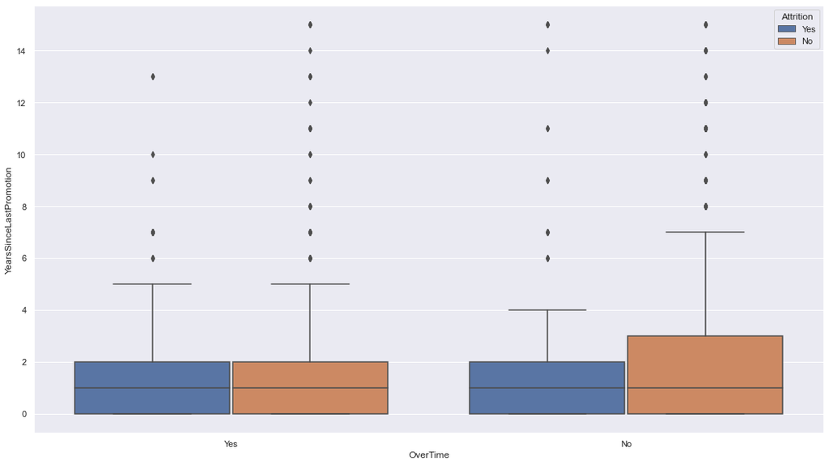

```python
a= sns.boxplot( y = "YearsSinceLastPromotion",
                  x = "OverTime",
                  hue= df['Attrition'],
                  data = df)

a.figure.set_size_inches(18,10)
plt
```

**Fact:**

- Most Employees with around 0-3 years since promotion are leaving the company irrespective of Overtime done or not. Here our hypothesis fails to hold true!

# SUMMARY

### Top 5 Variables which has affected Attrition:

**1. OverTime**

- Attrition rate for Overtime shows a promising 30.53%, so its one of the important variables to look for.

**2. Job Level**

- It is negatively Correlated to Attrition. Lower the Job Level, higher the Attrition Rate. Attrition rate for lowest Job Level i.e. 1, shows 26.34%.

**3. Monthly Income**

- It is negatively correlated to attrition. Lesser the Monthly Income, higher the attrition rate. Employees with salary around 2500 are more prone to leave the company.

**5. Years in Current Role**

- Its negatively correlated to Attrition. Lesser the Years in Current role, Higher the attrition rate. People with 0 to 2 years in current role show maximum frequency of attrition.

### To reduce the attrition rate I would recommend:

1. **Offer support**: Provide work-life balance programs and flexible work arrangements that help employees manage their workload and reduce overtime. Offer mentorship and coaching programs that support employees in their current roles and help them develop the skills required for future roles.
2. **Encourage career growth**: Provide career advancement opportunities, training programs, and mentorship to support employee progression to higher job levels.
3. **Offer competitive compensation**: Offer competitive salaries and benefits that align with the market standards and recognize and reward long-serving employees for their commitment to the organization.
4. **Foster a positive work environment**: Provide a positive and inclusive work environment that encourages employee engagement and job satisfaction.
5. **Gather employee feedback**: Conduct regular employee engagement surveys to understand the underlying reasons for employee turnover and take corrective actions accordingly.